# Praca domowa 6

Aleksandra Dąbrowska

4 April 2017

Pobierz plik `df.rda` i wykonaj na nim poniższe zadania https://github.com/pbiecek/LinearModels/blob/master/MIMUW_2017/Lab/df.rda

```r
load("df.rda")
```

1. Wykonaj analizę jednokierunkową wariancji ze zmienną `V1`. Ustaw poziom `B` jako poziom referencyjny.

```r
df$V1 <- relevel(df$V1, ref = "B")

anova(lm(y~V1, data=df))
```

```
## Analysis of Variance Table
##
## Response: y
##            Df Sum Sq Mean Sq F value    Pr(>F)
## V1          2  15813  7906.6  139.16 < 2.2e-16 ***
## Residuals 297  16874    56.8
## ---
## Signif. codes:  0 '***' 0.001 '**' 0.01 '*' 0.05 '.' 0.1 ' ' 1
```

Zmienna `V1` jest istotnie objaśnia zmienną `y`.

2. Połącz w zmiennych `V1` i `V2` poziomy `B` i `C` ze sobą, a następnie wykonaj test weryfikujący istotność interakcji.

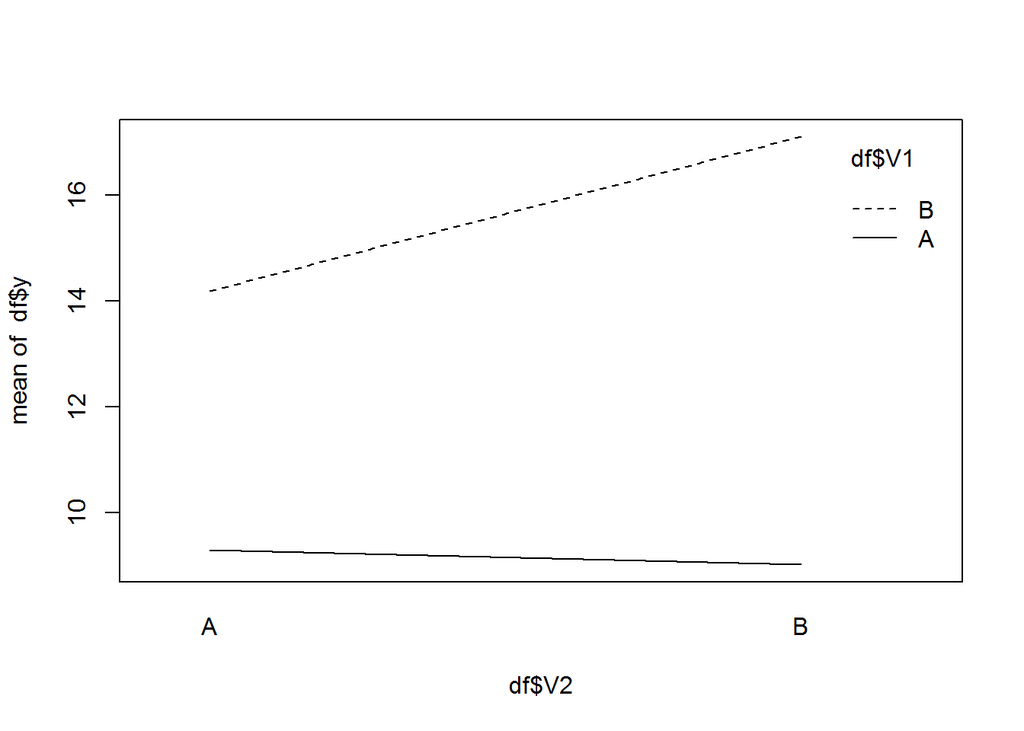

```r
df$V1[df$V1=="C"] <- "B"
df$V2[df$V2=="C"] <- "B"
df$V1<-droplevels(df$V1)
df$V2<-droplevels(df$V2)

interaction.plot(df$V2,df$V1,df$y)
```

```r
model.interakcja<-lm(y~V1*V2,data=df)
model.suma <- lm(y~V1+V2,data=df)

anova(model.interakcja)
```

```
## Analysis of Variance Table
##
## Response: y
##            Df  Sum Sq Mean Sq F value    Pr(>F)
## V1          1  3343.0  3343.0 34.1446 1.348e-08 ***
## V2          1   210.2   210.2  2.1468    0.1439
## V1:V2       1   153.7   153.7  1.5701    0.2112
## Residuals 296 28980.5    97.9
## ---
## Signif. codes:  0 '***' 0.001 '**' 0.01 '*' 0.05 '.' 0.1 ' ' 1
```

```r
anova(model.suma)
```

```
## Analysis of Variance Table
##
## Response: y
##            Df  Sum Sq Mean Sq F value    Pr(>F)
## V1          1  3343.0  3343.0 34.0792 1.385e-08 ***
## V2          1   210.2   210.2  2.1426    0.1443
## Residuals 297 29134.2    98.1
## ---
## Signif. codes:  0 '***' 0.001 '**' 0.01 '*' 0.05 '.' 0.1 ' ' 1
```

```r
anova(model.interakcja,model.suma)
```

```
## Analysis of Variance Table
##
## Model 1: y ~ V1 * V2
## Model 2: y ~ V1 + V2
##   Res.Df   RSS Df Sum of Sq      F Pr(>F)
## 1    296 28981
## 2    297 29134 -1   -153.72 1.5701 0.2112
```

Przeprowadzony test pokazuje, że nie ma interakcji między zmiennymi `V1` i `V2`.

3. Dla zmiennej `V3` porównaj wyniki dla różnych kontrastów, przynajmniej Helmerta, poly i sum.

```r
summary(lm(y~V3, data=df, contrasts = contr.helmert(10)))
```

```
##
## Call:
## lm(formula = y ~ V3, data = df, contrasts = contr.helmert(10))
##
## Residuals:
##      Min       1Q   Median       3Q      Max
## -16.4375  -8.8835  -0.7477   6.8117  28.6437
##
## Coefficients:
##             Estimate Std. Error t value Pr(>|t|)
## (Intercept)  15.9471     1.9132   8.335 3.14e-15 ***
## V3B          -3.3902     2.7057  -1.253   0.2112
## V3C          -2.8994     2.7057  -1.072   0.2848
## V3D          -2.2470     2.7057  -0.830   0.4069
## V3E          -0.9555     2.7057  -0.353   0.7242
## V3F          -2.2243     2.7057  -0.822   0.4117
## V3G          -2.4525     2.7057  -0.906   0.3655
## V3H           0.9105     2.7057   0.337   0.7367
## V3I          -2.4153     2.7057  -0.893   0.3728
## V3J          -5.3778     2.7057  -1.988   0.0478 *
## ---
## Signif. codes:  0 '***' 0.001 '**' 0.01 '*' 0.05 '.' 0.1 ' ' 1
##
## Residual standard error: 10.48 on 290 degrees of freedom
## Multiple R-squared:  0.02578,    Adjusted R-squared:  -0.004453
## F-statistic: 0.8527 on 9 and 290 DF,  p-value: 0.5682
```

```r
summary(lm(y~V3,data=df, contrasts = contr.poly(10)))
```

```
##
## Call:
## lm(formula = y ~ V3, data = df, contrasts = contr.poly(10))
##
## Residuals:
##      Min       1Q   Median       3Q      Max
## -16.4375  -8.8835  -0.7477   6.8117  28.6437
##
## Coefficients:
##             Estimate Std. Error t value Pr(>|t|)
## (Intercept)  15.9471     1.9132   8.335 3.14e-15 ***
## V3B          -3.3902     2.7057  -1.253   0.2112
## V3C          -2.8994     2.7057  -1.072   0.2848
## V3D          -2.2470     2.7057  -0.830   0.4069
## V3E          -0.9555     2.7057  -0.353   0.7242
## V3F          -2.2243     2.7057  -0.822   0.4117
## V3G          -2.4525     2.7057  -0.906   0.3655
## V3H           0.9105     2.7057   0.337   0.7367
## V3I          -2.4153     2.7057  -0.893   0.3728
## V3J          -5.3778     2.7057  -1.988   0.0478 *
## ---
## Signif. codes:  0 '***' 0.001 '**' 0.01 '*' 0.05 '.' 0.1 ' ' 1
##
## Residual standard error: 10.48 on 290 degrees of freedom
## Multiple R-squared:  0.02578,    Adjusted R-squared:  -0.004453
## F-statistic: 0.8527 on 9 and 290 DF,  p-value: 0.5682
```

```r
summary(lm(y~V3,data=df, contrasts = contr.sum(10)))
```

```
##
## Call:
## lm(formula = y ~ V3, data = df, contrasts = contr.sum(10))
##
## Residuals:
##      Min       1Q   Median       3Q      Max
## -16.4375  -8.8835  -0.7477   6.8117  28.6437
##
## Coefficients:
##             Estimate Std. Error t value Pr(>|t|)
## (Intercept)  15.9471     1.9132   8.335 3.14e-15 ***
## V3B          -3.3902     2.7057  -1.253   0.2112
## V3C          -2.8994     2.7057  -1.072   0.2848
## V3D          -2.2470     2.7057  -0.830   0.4069
## V3E          -0.9555     2.7057  -0.353   0.7242
## V3F          -2.2243     2.7057  -0.822   0.4117
## V3G          -2.4525     2.7057  -0.906   0.3655
## V3H           0.9105     2.7057   0.337   0.7367
## V3I          -2.4153     2.7057  -0.893   0.3728
## V3J          -5.3778     2.7057  -1.988   0.0478 *
## ---
## Signif. codes:  0 '***' 0.001 '**' 0.01 '*' 0.05 '.' 0.1 ' ' 1
##
## Residual standard error: 10.48 on 290 degrees of freedom
## Multiple R-squared:  0.02578,    Adjusted R-squared:  -0.004453
## F-statistic: 0.8527 on 9 and 290 DF,  p-value: 0.5682
```

```r
summary(lm(y~V3,data=df, contrasts = contr.sdif(10)))
```

```
##
## Call:
## lm(formula = y ~ V3, data = df, contrasts = contr.sdif(10))
##
## Residuals:
##      Min       1Q   Median       3Q      Max
## -16.4375  -8.8835  -0.7477   6.8117  28.6437
##
## Coefficients:
##             Estimate Std. Error t value Pr(>|t|)
## (Intercept)  15.9471     1.9132   8.335 3.14e-15 ***
## V3B          -3.3902     2.7057  -1.253   0.2112
## V3C          -2.8994     2.7057  -1.072   0.2848
## V3D          -2.2470     2.7057  -0.830   0.4069
## V3E          -0.9555     2.7057  -0.353   0.7242
## V3F          -2.2243     2.7057  -0.822   0.4117
## V3G          -2.4525     2.7057  -0.906   0.3655
## V3H           0.9105     2.7057   0.337   0.7367
## V3I          -2.4153     2.7057  -0.893   0.3728
## V3J          -5.3778     2.7057  -1.988   0.0478 *
## ---
## Signif. codes:  0 '***' 0.001 '**' 0.01 '*' 0.05 '.' 0.1 ' ' 1
##
## Residual standard error: 10.48 on 290 degrees of freedom
## Multiple R-squared:  0.02578,    Adjusted R-squared:  -0.004453
## F-statistic: 0.8527 on 9 and 290 DF,  p-value: 0.5682
```

```r
summary(lm(y~V3,data=df, contrasts = contr.treatment(10)))
```

```
##
## Call:
## lm(formula = y ~ V3, data = df, contrasts = contr.treatment(10))
##
## Residuals:
##      Min       1Q   Median       3Q      Max
## -16.4375  -8.8835  -0.7477   6.8117  28.6437
##
## Coefficients:
##             Estimate Std. Error t value Pr(>|t|)
## (Intercept)  15.9471     1.9132   8.335 3.14e-15 ***
## V3B          -3.3902     2.7057  -1.253   0.2112
## V3C          -2.8994     2.7057  -1.072   0.2848
## V3D          -2.2470     2.7057  -0.830   0.4069
## V3E          -0.9555     2.7057  -0.353   0.7242
## V3F          -2.2243     2.7057  -0.822   0.4117
## V3G          -2.4525     2.7057  -0.906   0.3655
## V3H           0.9105     2.7057   0.337   0.7367
## V3I          -2.4153     2.7057  -0.893   0.3728
## V3J          -5.3778     2.7057  -1.988   0.0478 *
## ---
## Signif. codes:  0 '***' 0.001 '**' 0.01 '*' 0.05 '.' 0.1 ' ' 1
##
## Residual standard error: 10.48 on 290 degrees of freedom
## Multiple R-squared:  0.02578,    Adjusted R-squared:  -0.004453
## F-statistic: 0.8527 on 9 and 290 DF,  p-value: 0.5682
```

Wszytskie zastosowane kontrasty wskazują niewielką istotność poziomu `J` zmiennej `V3`

4. Wykonaj test post hoc dla zmiennej `V3`. Które poziomy różnią się pomiędzy sobą?

```r
model <- aov(y~V3, data=df)
HSD.test(model,"V3",console=TRUE)
```

```
##
## Study: model ~ "V3"
##
## HSD Test for y
##
## Mean Square Error:  109.8092
##
## V3,  means
##
##          y       std  r         Min      Max
## A 15.94708  9.909170 30 -0.49038520 37.67078
## B 12.55691  9.615747 30 -0.72225742 35.94348
## C 13.04770  9.677720 30 -1.38321875 30.79361
## D 13.70005 13.007236 30 -1.55076953 42.34373
## E 14.99162 10.883890 30 -0.09663986 42.14185
## F 13.72283  9.001764 30 -1.43271495 34.87147
## G 13.49456  9.870767 30 -0.45813374 41.11890
## H 16.85756  9.929838 30  0.76688651 38.71058
## I 13.53177 11.355871 30 -0.17902314 38.72374
## J 10.56928 10.959496 30 -0.88269015 32.22231
##
## alpha: 0.05 ; Df Error: 290
## Critical Value of Studentized Range: 4.509303
##
## Honestly Significant Difference: 8.627165
##
## Means with the same letter are not significantly different.
##
## Groups, Treatments and means
## a     H   16.86
## a     A   15.95
## a     E   14.99
## a     F   13.72
## a     D   13.7
## a     I   13.53
## a     G   13.49
## a     C   13.05
## a     B   12.56
## a     J   10.57
```

Test HSD Tukey’a pokazuje, że nie ma istotnych różnic między poziomami.

```r
#tutaj pokazuje ze mamy roznice miedzy grupa "H","A" i "J"
LSD.test(model,"V3",console=TRUE)
```

```
##
## Study: model ~ "V3"
##
## LSD t Test for y
##
## Mean Square Error:  109.8092
##
## V3,  means and individual ( 95 %) CI
##
##          y       std  r       LCL      UCL         Min      Max
## A 15.94708  9.909170 30 12.181577 19.71258 -0.49038520 37.67078
## B 12.55691  9.615747 30  8.791402 16.32241 -0.72225742 35.94348
## C 13.04770  9.677720 30  9.282197 16.81320 -1.38321875 30.79361
## D 13.70005 13.007236 30  9.934545 17.46555 -1.55076953 42.34373
## E 14.99162 10.883890 30 11.226121 18.75713 -0.09663986 42.14185
## F 13.72283  9.001764 30  9.957326 17.48833 -1.43271495 34.87147
## G 13.49456  9.870767 30  9.729054 17.26006 -0.45813374 41.11890
## H 16.85756  9.929838 30 13.092057 20.62306  0.76688651 38.71058
## I 13.53177 11.355871 30  9.766269 17.29727 -0.17902314 38.72374
## J 10.56928 10.959496 30  6.803774 14.33478 -0.88269015 32.22231
##
## alpha: 0.05 ; Df Error: 290
## Critical Value of t: 1.968178
##
## t-Student: 1.968178
## Alpha    : 0.05
## Least Significant Difference 5.325225
## Means with the same letter are not significantly different
##
##
## Groups, Treatments and means
## a     H   16.85756
## a     A   15.94708
## ab    E   14.99162
## ab    F   13.72283
## ab    D   13.70005
## ab    I   13.53177
## ab    G   13.49456
## ab    C   13.0477
## ab    B   12.55691
## b     J   10.56928
```

Test LSD pokazuje że istnieją różnice między grupami `H`, `A` i `J`.

5. Zweryfikuj istotność zależności od zmiennej `V4`

```r
anova(lm(y~V4,data=df))
```

```
## Analysis of Variance Table
##
## Response: y
##            Df Sum Sq Mean Sq F value  Pr(>F)
## V4          1    342  342.14  3.1522 0.07685 .
## Residuals 298  32345  108.54
## ---
## Signif. codes:  0 '***' 0.001 '**' 0.01 '*' 0.05 '.' 0.1 ' ' 1
```

Zmienna `V4` w niewielkim stopniu (prawie na poziomie istotności) objaśnia zmienną `y`.

6. Czy istotna jest interakcja pomiędzy V4 a V1? Jak pokazać tę zależność.

```r
load("df.rda")
anova(lm(y~V4*V1,data=df))
```

```
## Analysis of Variance Table
##
## Response: y
##            Df  Sum Sq Mean Sq  F value  Pr(>F)
## V4          1   342.1   342.1   6.0616 0.01439 *
## V1          2 15554.6  7777.3 137.7892 < 2e-16 ***
## V4:V1       2   196.3    98.1   1.7388 0.17754
## Residuals 294 16594.4    56.4
## ---
## Signif. codes:  0 '***' 0.001 '**' 0.01 '*' 0.05 '.' 0.1 ' ' 1
```

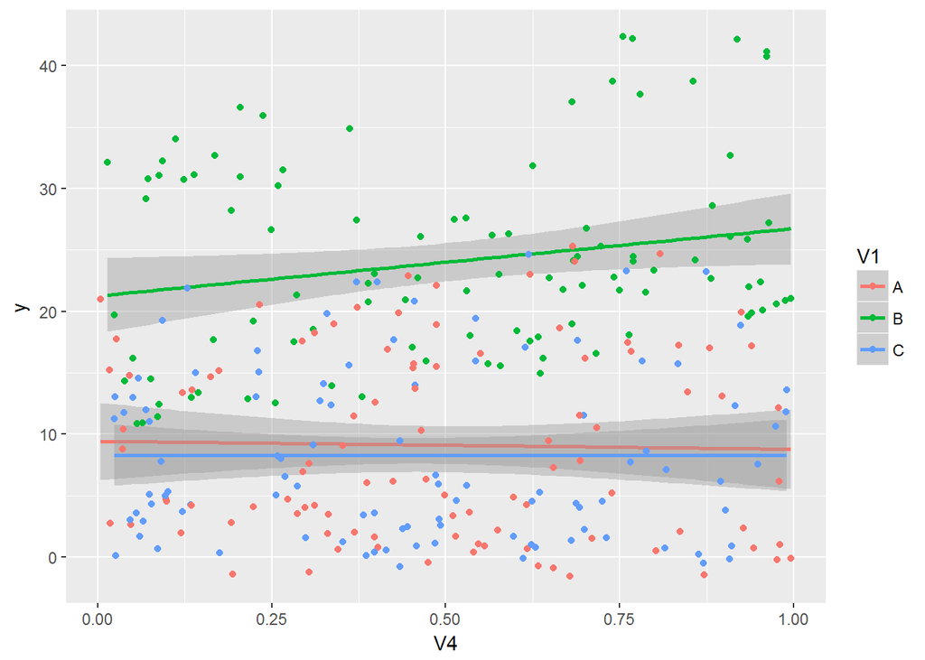

```r
ggplot(df,aes(V4,y,color=V1))+stat_smooth(method=lm)+geom_point()
```

Nie mamy istotnej zależności między zmiennymi `V1` i `V4`.

7. Zweryfikuj zależność od zmiennej `V5`. A co jeżeli ta zależność nie jest liniowa? Sprawdź zależność od wielomianu stopnia 3.

```r
anova(lm(y~V5, data=df))
```

```
## Analysis of Variance Table
##
## Response: y
##            Df Sum Sq Mean Sq F value Pr(>F)
## V5          1     37   37.18  0.3393 0.5607
## Residuals 298  32650  109.56
```

```r
anova(lm(y~poly(V5,3),data=df))
```

```
## Analysis of Variance Table
##
## Response: y
##              Df Sum Sq Mean Sq F value    Pr(>F)
## poly(V5, 3)   3  15806  5268.8  92.386 < 2.2e-16 ***
## Residuals   296  16881    57.0
## ---
## Signif. codes:  0 '***' 0.001 '**' 0.01 '*' 0.05 '.' 0.1 ' ' 1
```

```r
summary(lm(y~poly(V5,3),data=df))
```

```
##
## Call:
## lm(formula = y ~ poly(V5, 3), data = df)
##
## Residuals:
##    Min     1Q Median     3Q    Max
## -8.176 -5.598 -4.141  7.145 16.273
##
## Coefficients:
##              Estimate Std. Error t value Pr(>|t|)
## (Intercept)    13.842      0.436  31.747   <2e-16 ***
## poly(V5, 3)1   -6.098      7.552  -0.807    0.420
## poly(V5, 3)2  125.549      7.552  16.625   <2e-16 ***
## poly(V5, 3)3    2.572      7.552   0.341    0.734
## ---
## Signif. codes:  0 '***' 0.001 '**' 0.01 '*' 0.05 '.' 0.1 ' ' 1
##
## Residual standard error: 7.552 on 296 degrees of freedom
## Multiple R-squared:  0.4836, Adjusted R-squared:  0.4783
## F-statistic: 92.39 on 3 and 296 DF,  p-value: < 2.2e-16
```

```r
summary(lm(y~poly(V5,2),data=df))
```

```
##
## Call:
## lm(formula = y ~ poly(V5, 2), data = df)
##
## Residuals:
##    Min     1Q Median     3Q    Max
## -8.009 -5.596 -4.211  7.178 16.351
##
## Coefficients:
##              Estimate Std. Error t value Pr(>|t|)
## (Intercept)   13.8419     0.4354  31.794   <2e-16 ***
## poly(V5, 2)1  -6.0975     7.5406  -0.809    0.419
## poly(V5, 2)2 125.5492     7.5406  16.650   <2e-16 ***
## ---
## Signif. codes:  0 '***' 0.001 '**' 0.01 '*' 0.05 '.' 0.1 ' ' 1
##
## Residual standard error: 7.541 on 297 degrees of freedom
## Multiple R-squared:  0.4834, Adjusted R-squared:  0.4799
## F-statistic: 138.9 on 2 and 297 DF,  p-value: < 2.2e-16
```

Dla zmiennej V5 wystarczy wziąć już wielomian drugiego stopnia. Przy takim przekształceniu zmienna `poly(V5,3)` w istotnym stopniu objaśnia `y`.

8. Zbuduj nową zmienną `NV := V4 - 2*V5`. Zbadaj związek z tą zmienną.

```r
df$NV <- df$V4-2*df$V5
anova(lm(y~NV,data=df))
```

```
## Analysis of Variance Table
##
## Response: y
##            Df Sum Sq Mean Sq F value Pr(>F)
## NV          1    129  128.89  1.1797 0.2783
## Residuals 298  32558  109.26
```

Nowa zmienna `NV` nie ma istotnego wpływu na objaśnianie `y`.

9. Wybierz model optymalny według kryterium BIC - zrób przegląd pełny wszystkich modeli.

```r
zmienne <- c("V1","V2","V3","V4","V5","poly(V5,2)","V6","V7","V8","V9","V10")

wspolczynniki <- (bincombinations(length(zmienne))==1)[-1,]
parametry <- matrix(0,nrow(wspolczynniki),3)
for (i in 1:nrow(wspolczynniki)) {
     form <- as.formula(paste("y~(", paste(zmienne[wspolczynniki[i,]], collapse="+"),")^2"))
     model <- lm(form, data=df)
     parametry[i,1] <- AIC(model, k=log(nrow(df)))
     parametry[i,2] <- model$rank
     parametry[i,3] <- AIC(model)
 }

as.formula(paste("y~",paste(zmienne[wspolczynniki[which.min(parametry[,1]),]], collapse="+")))
```

```
## y ~ V1 + V4 + poly(V5, 2)
```

10. Wybierz model optymalny według kryterium AIC - użyj funkcji step.

```r
step.aic <- stepAIC(lm(y~.+poly(V5,2),data=df),direction = "backward")
```

```
## Start:  AIC=354.44
## y ~ V1 + V2 + V3 + V4 + V5 + V6 + V7 + V8 + V9 + V10 + NV + poly(V5,
##     2)
##
##
## Step:  AIC=354.44
## y ~ V1 + V2 + V3 + V4 + V5 + V6 + V7 + V8 + V9 + V10 + poly(V5,
##     2)
##
##
## Step:  AIC=354.44
## y ~ V1 + V2 + V3 + V4 + V6 + V7 + V8 + V9 + V10 + poly(V5, 2)
##
##               Df Sum of Sq     RSS     AIC
## - V2           2       0.5   844.9  350.62
## - V3           9      46.0   890.3  352.34
## - V7           1       0.1   844.5  352.48
## - V6           1       0.4   844.8  352.59
## - V10          1       1.1   845.4  352.82
## - V9           1       4.5   848.8  354.03
## <none>                       844.4  354.44
## - V8           1       7.2   851.5  354.97
## - V4           1     342.1  1186.4  454.48
## - V1           2   14692.3 15536.6 1224.15
## - poly(V5, 2)  2   14912.9 15757.3 1228.38
##
## Step:  AIC=350.62
## y ~ V1 + V3 + V4 + V6 + V7 + V8 + V9 + V10 + poly(V5, 2)
##
##               Df Sum of Sq     RSS     AIC
## - V3           9      46.2   891.0  348.58
## - V7           1       0.1   845.0  348.67
## - V6           1       0.6   845.4  348.82
## - V10          1       1.1   845.9  349.00
## - V9           1       4.5   849.4  350.21
## <none>                       844.9  350.62
## - V8           1       7.4   852.3  351.24
## - V4           1     342.8  1187.6  450.78
## - V1           2   14825.6 15670.5 1222.73
## - poly(V5, 2)  2   14976.7 15821.6 1225.60
```

[output cut: 45 more lines]

```
## <none>                       891.8  342.84
## - V8           1       7.5   899.4  343.37
## - V4           1     337.1  1228.9  437.03
## - V1           2   15031.7 15923.6 1203.53
## - poly(V5, 2)  2   15887.3 16779.1 1219.23
##
## Step:  AIC=342.41
## y ~ V1 + V4 + V8 + poly(V5, 2)
##
##               Df Sum of Sq     RSS     AIC
## <none>                       896.5  342.41
## - V8           1       7.5   903.9  342.89
## - V4           1     347.0  1243.5  438.58
## - V1           2   15055.5 15952.0 1202.07
## - poly(V5, 2)  2   15883.2 16779.7 1217.24
```

11. Wykonaj diagnostykę reszt. Czy są obserwacje odstające/wpływowe?

```r
model <- lm(y ~ V1 + V4 + V8+ poly(V5, 2),data=df)
summary(model)
```

```
##
## Call:
## lm(formula = y ~ V1 + V4 + V8 + poly(V5, 2), data = df)
##
## Residuals:
##     Min      1Q  Median      3Q     Max
## -4.4337 -1.1498 -0.0321  1.1798  4.8362
##
## Coefficients:
##              Estimate Std. Error t value Pr(>|t|)
## (Intercept)    6.9465     0.2666  26.058  < 2e-16 ***
## V1B           15.3996     0.2503  61.536  < 2e-16 ***
## V1C            0.3046     0.2482   1.227  0.22069
## V4             3.7523     0.3523  10.650  < 2e-16 ***
## V8            -0.1636     0.1048  -1.561  0.11961
## poly(V5, 2)1   5.0935     1.7649   2.886  0.00419 **
## poly(V5, 2)2 126.4910     1.7568  72.000  < 2e-16 ***
## ---
## Signif. codes:  0 '***' 0.001 '**' 0.01 '*' 0.05 '.' 0.1 ' ' 1
##
## Residual standard error: 1.749 on 293 degrees of freedom
## Multiple R-squared:  0.9726, Adjusted R-squared:  0.972
## F-statistic:  1732 on 6 and 293 DF,  p-value: < 2.2e-16
```

W końcowym modelu będziemy rozważać zmienne `V1`, `V4` i `poly(V5,2)`.

```r
model <- lm(y ~ V1 + V4 + poly(V5, 2),data=df)

summary(model)
```

```
##
## Call:
## lm(formula = y ~ V1 + V4 + poly(V5, 2), data = df)
##
## Residuals:
##     Min      1Q  Median      3Q     Max
## -4.5937 -1.1985  0.0163  1.1776  4.7132
##
## Coefficients:
##              Estimate Std. Error t value Pr(>|t|)
## (Intercept)    6.7874     0.2469  27.487  < 2e-16 ***
## V1B           15.3523     0.2490  61.650  < 2e-16 ***
## V1C            0.3004     0.2488   1.208  0.22819
## V4             3.7713     0.3530  10.685  < 2e-16 ***
## poly(V5, 2)1   4.8291     1.7611   2.742  0.00648 **
## poly(V5, 2)2 126.5130     1.7610  71.840  < 2e-16 ***
## ---
## Signif. codes:  0 '***' 0.001 '**' 0.01 '*' 0.05 '.' 0.1 ' ' 1
##
## Residual standard error: 1.753 on 294 degrees of freedom
## Multiple R-squared:  0.9723, Adjusted R-squared:  0.9719
## F-statistic:  2067 on 5 and 294 DF,  p-value: < 2.2e-16
```

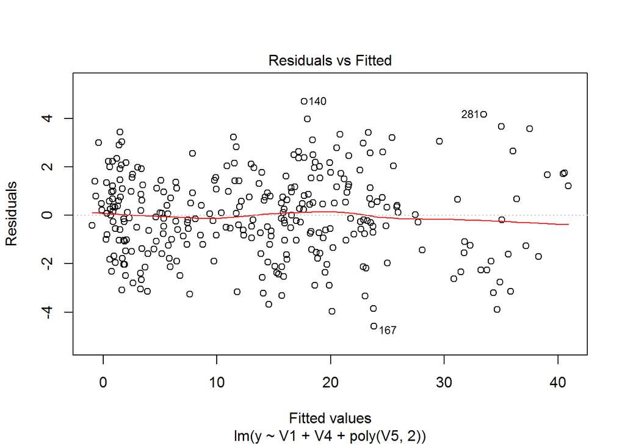

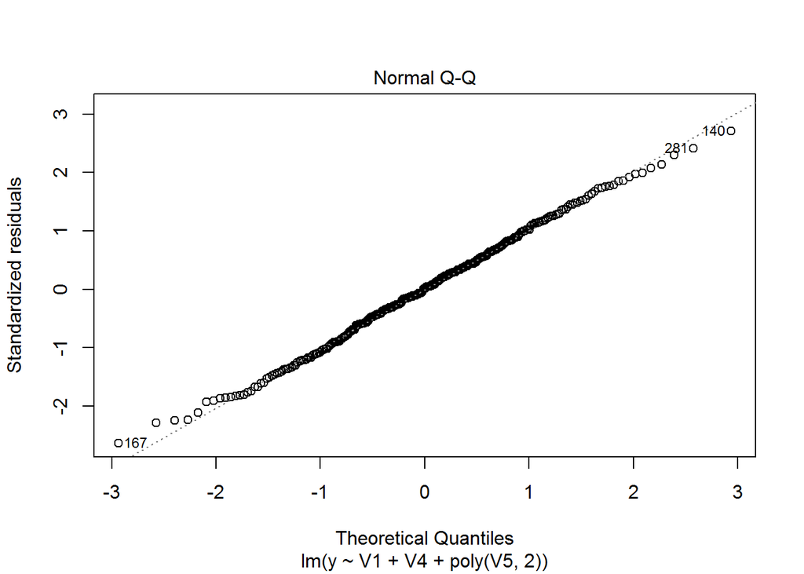

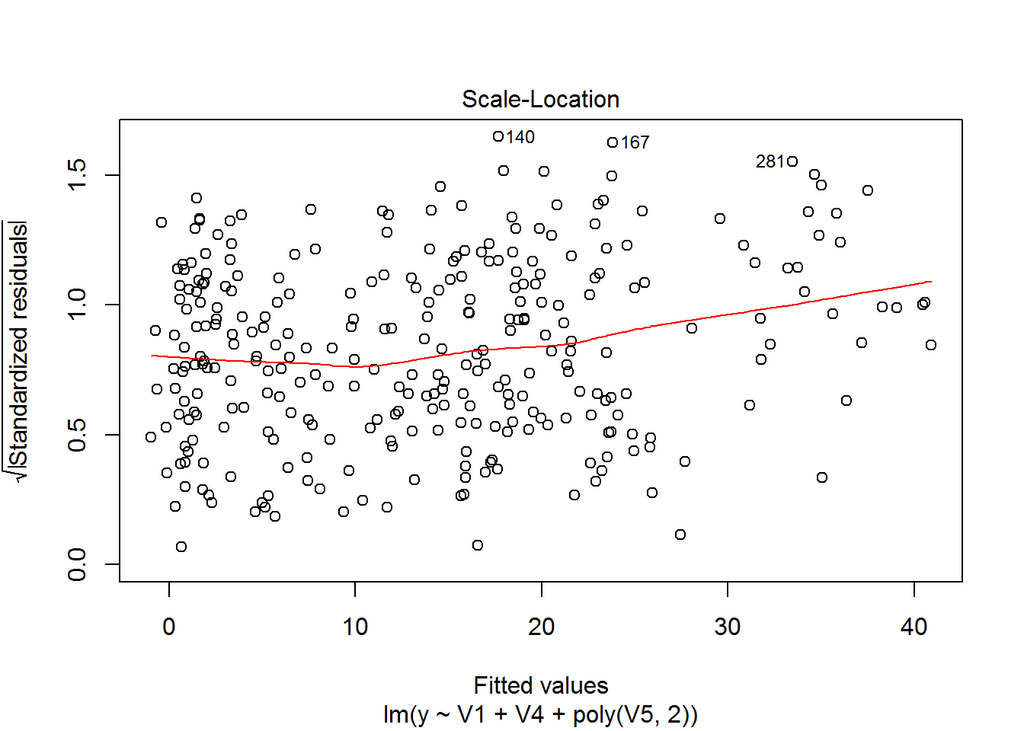

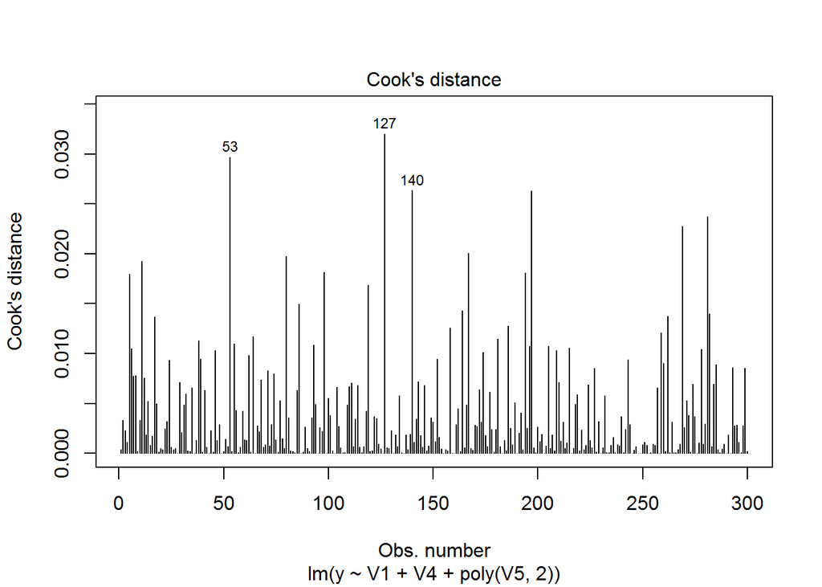

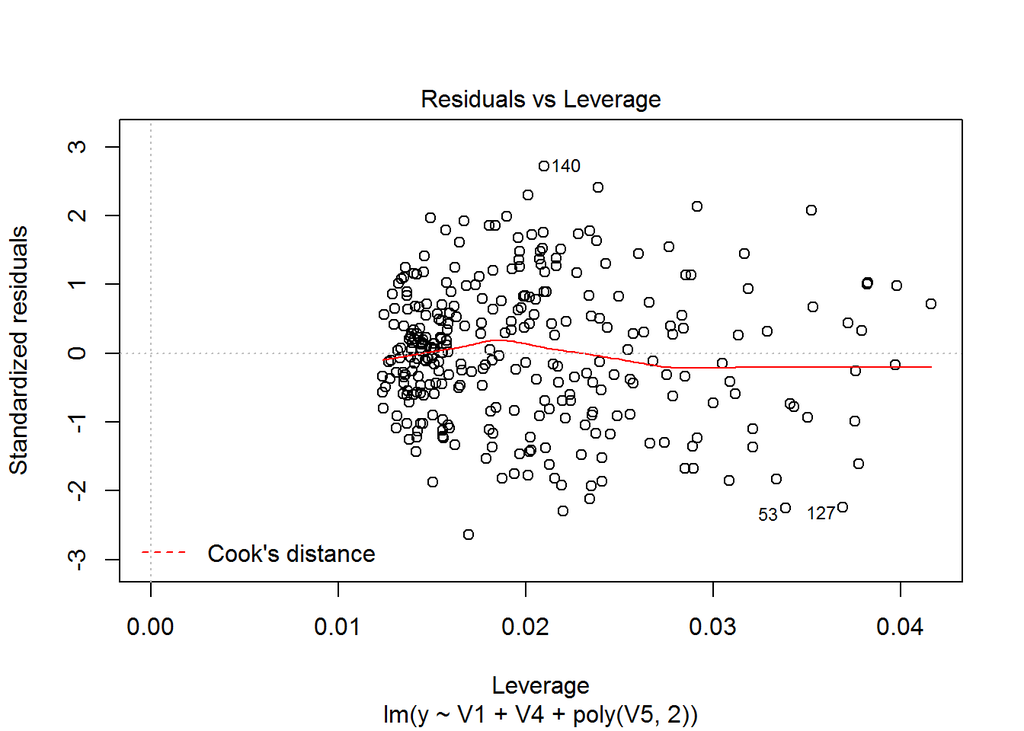

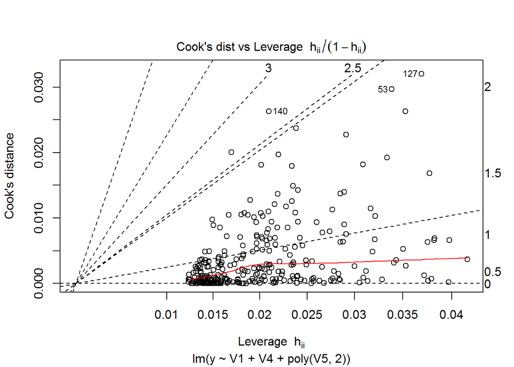

```r
plot(model,which=1:6)
```

Dla wybranego modelu wykonujemy testy diagnostyczne.

```r
bptest(model)
```

```
##
##  studentized Breusch-Pagan test
##
## data:  model
## BP = 32.242, df = 5, p-value = 5.321e-06
```

```r
dwtest(model)
```

```
##
##  Durbin-Watson test
##
## data:  model
## DW = 2.0732, p-value = 0.7531
## alternative hypothesis: true autocorrelation is greater than 0
```

```r
bgtest(model)
```

```
##
##  Breusch-Godfrey test for serial correlation of order up to 1
##
## data:  model
## LM test = 0.41097, df = 1, p-value = 0.5215
```

Nie ma autokorelacji rzędu 1 między resztami, co sugeruje ich niezależność.

```r
shapiro.test(model$residuals)
```

```
##
##  Shapiro-Wilk normality test
##
## data:  model$residuals
## W = 0.99701, p-value = 0.8548
```

```r
raintest(model)
```

```
##
##  Rainbow test
##
## data:  model
## Rain = 0.92273, df1 = 150, df2 = 144, p-value = 0.6871
```

```r
resettest(model)
```

```
##
##  RESET test
##
## data:  model
## RESET = 0.056705, df1 = 2, df2 = 292, p-value = 0.9449
```

12. Zweryfikuj istotność interakcji `V6` i `V7`.

```r
anova(lm(y~V6*V7, data=df))
```

```
## Analysis of Variance Table
##
## Response: y
##            Df Sum Sq Mean Sq F value Pr(>F)
## V6          1    105 105.494  0.9646 0.3268
## V7          1    177 177.389  1.6220 0.2038
## V6:V7       1     33  33.162  0.3032 0.5823
## Residuals 296  32371 109.363
```

Nie ma interakcji między zmiennymi `V6` i `V7`.

13. Porównaj wyniki z wynikami funkcji `ctree` pakiet `partykit`.

```r
model_ctree <- ctree(y ~ V4+V1 + poly(V5,2),data=df)

model_ctree
```

```
##
## Model formula:
## y ~ V4 + V1 + poly(V5, 2)
##
## Fitted party:
## [1] root
## |   [2] V1 in A, C: 8.714 (n = 200, err = 10638.2)
## |   [3] V1 in B: 24.099 (n = 100, err = 6269.2)
##
## Number of inner nodes:    1
## Number of terminal nodes: 2
```

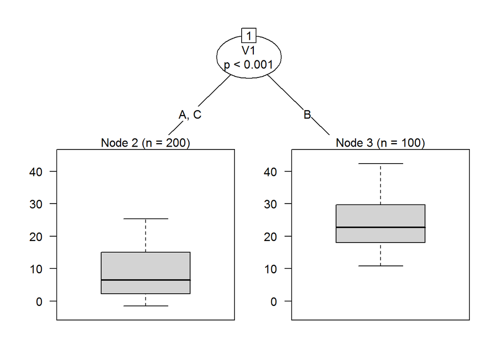

```r
plot(model_ctree)
```

Wynik funkcji `ctree` sugeruje, że jedyną istotną zmienną w tym modelu jest zmienna `V1` której poziomy zostały podzielone na dwie grupy `A` i `C` oraz `B`.